# Cyclist-bike-share_DAcourse_capstone

Mahesh

08/03/2022

#1) Loading libraries

```r
library(tidyverse)
library(janitor)
library(lubridate)
```

```r
library(ggplot2)
```

#2) Loading 12 monthly csv files into 12 data.frames

```r
df1<-read.csv("./Data/t1.csv")
df2<-read.csv("./Data/t2.csv")
df3<-read.csv("./Data/t3.csv")
df4<-read.csv("./Data/t4.csv")
df5<-read.csv("./Data/t5.csv")
df6<-read.csv("./Data/t6.csv")
df7<-read.csv("./Data/t7.csv")
df8<-read.csv("./Data/t8.csv")
df9<-read.csv("./Data/t9.csv")
df10<-read.csv("./Data/t10.csv")
df11<-read.csv("./Data/t11.csv")
df12<-read.csv("./Data/t12.csv")
```

#3) Combine 12 data.frames into one data.frame

```r
bike_rides <- bind_rows(df1,df2,df3,df4,df5,df6,df7,df8,df9,df10,df11,df12) #Other option rbind()
dim(bike_rides)
str(bike_rides)
unique(bike_rides$rideable_type)
unique(bike_rides$member_casual)
summarize_all(bike_rides,n_distinct)
```

#4) Remove empty rows and columns

```r
bike_rides <- janitor::remove_empty(bike_rides,which = c("cols"))
bike_rides <- janitor::remove_empty(bike_rides,which = c("rows"))
dim(bike_rides) #Same as before this step
```

#5) Convert Date/Time stamp to Date/Time

```r
bike_rides$started_at <- lubridate::ymd_hms(bike_rides$started_at) #Or as_datetime()
bike_rides$ended_at <- lubridate::ymd_hms(bike_rides$ended_at)
```

#6) Add extra columns for date, month, day, year, day_of_week

```r
bike_rides$date <- as.Date(bike_rides$started_at) #The default format is yyyy-mm-dd
bike_rides$month <- format(as.Date(bike_rides$date), "%m")
bike_rides$day <- format(as.Date(bike_rides$date), "%d")
bike_rides$year <- format(as.Date(bike_rides$date), "%Y")
bike_rides$day_of_week <- format(as.Date(bike_rides$date), "%A")
dim(bike_rides) #5595063      18
```

#7) Calculate ride length in seconds

```r
bike_rides$ride_length <- difftime(bike_rides$ended_at,bike_rides$started_at)
bike_rides$ride_length <- as.numeric(bike_rides$ride_length)
dim(filter(bike_rides,bike_rides$ride_length<0)) #147  19
dim(filter(bike_rides,bike_rides$ride_length>0)) #5594410      19
dim(filter(bike_rides,bike_rides$ride_length==0)) #506  19
```

#8) Remove bad data (rides with negative and zero ride_length)

```r
all_trips_v2 <-  filter(bike_rides,bike_rides$ride_length>0) # %>%select(start_station_id,started_at,ended_at,ride_length)
summarize_all(all_trips_v2,n_distinct)
```

#9) Descriptive analysis on ride_length (all figures in seconds)

```r
summary(all_trips_v2$ride_length)
```

#10) Compare members and casual users

```r
aggregate(all_trips_v2$ride_length ~ all_trips_v2$member_casual, FUN = mean)
aggregate(all_trips_v2$ride_length ~ all_trips_v2$member_casual, FUN = median)
aggregate(all_trips_v2$ride_length ~ all_trips_v2$member_casual, FUN = max)
aggregate(all_trips_v2$ride_length ~ all_trips_v2$member_casual, FUN = min)
```

#11) See the average ride time by each day for members vs casual users

```r
aggregate(all_trips_v2$ride_length ~ all_trips_v2$member_casual + all_trips_v2$day_of_week, FUN = mean)
```

```r
all_trips_v2$day_of_week <- ordered(all_trips_v2$day_of_week, levels=c("Sunday", "Monday", "Tuesday", "Wednesday", "Thursday", "Friday", "Saturday"))
```

Now, let’s run the average ride time by each day for members vs casual users

```r
aggregate(all_trips_v2$ride_length ~ all_trips_v2$member_casual + all_trips_v2$day_of_week, FUN = mean)
```

#12) analyze ridership data by type and weekday

```r
all_trips_v3 <- all_trips_v2 %>%
  mutate(weekday = wday(started_at, label = TRUE)) %>% #creates weekday field using wday()
  group_by(member_casual, weekday) %>% #groups by usertype and weekday
  summarise(number_of_rides = n(),average_duration = mean(ride_length)) %>% #calculates the number of rides and average duration
  arrange(member_casual, weekday) # sorts
```

#13) visualize the number of rides by rider type

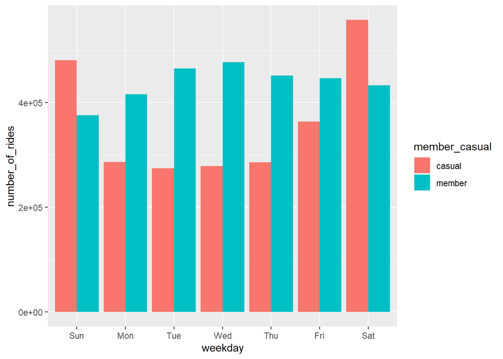

#14)visualize the number of rides by average duration

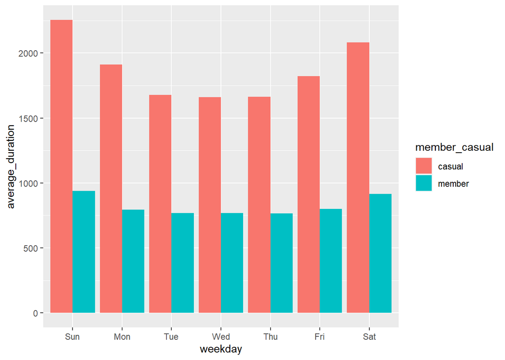

#STEP 15: EXPORT SUMMARY FILE FOR FURTHER ANALYSIS Create a csv file that we will visualize in Excel, Tableau, or my presentation software

```r
counts <- aggregate(all_trips_v2$ride_length ~ all_trips_v2$member_casual +
                      all_trips_v2$day_of_week, FUN = mean)
write.csv(counts, file = './avg_ride_length.csv')
```